# Readme

## How to use the computing tools

Use of the scripts for analyzing chembl data and visualizing biological pathways requires R to be installed. Download the current version of R at: https://cran.r-project.org/  
Extract the files from https://github.com/KyleVButler/ChemicalProbesDataMining into a new directory. If you want to use the ChEMBL data mining script, download the desired .db file (sqlite3 version) to the same directory. The files can be found at: https://www.ebi.ac.uk/chembl/downloads  
Analysis of the ChEMBL database can be accomplished with the script: chemblDataMining.R. Users can change the script to analyze the chembl .db file in different ways. To analyze other ChEMBL .db files besides CHEMBL22.db, change the line: `chembl_db <- src_sqlite("chembl_22.db", create = TRUE)`  
With R installed, open the terminal and go to the directory that contains the files from https://github.com/KyleVButler/ChemicalProbesDataMining Type R in the terminal to start R.  
Type `source("probeVisual.R")` to load the data visualization functions.

### Reactome networks

To visualize Reactome pathways with targetable nodes highlighted, type the following command into R at the terminal: `reactome_probe_network("Regulation of TP53 Activity through Methylation")`

You will see this plot appear:

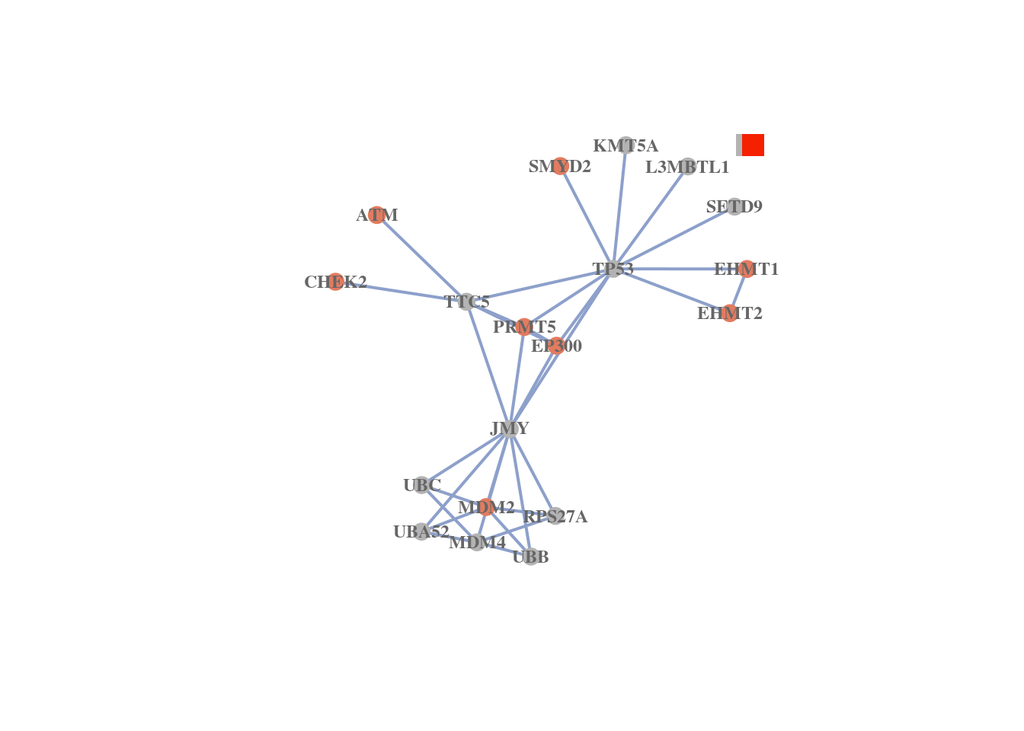

For other reactome networks, replace the pathway name in quotes with the name of the desired pathway. The punctuation must be exactly the same as shown in http://www.reactome.org/ This function uses the ReactomePA package.

### Annotate cytoscape windows

Cytoscape is a popular tool for network visualization. To highlight probe-targetable nodes in Cytoscape, construct your network in Cystoscape (cyREST must be installed, and is pre-installed in current version of Cytoscape). Make sure that the node names are Entrez gene IDs or Uniprot protein IDs. Then, in R, type `highlight_nodes_cytoscape()` This function uses the RCy3 package.

### Show target-probe network

The data set contains a subset of the IntAct protein-protein interaction database containing all proteins and interactions that are separated by probe-targetable proteins by one or two edges (interactions). To see the local probe pharmacology network for a c-Myc at a confidence score cutoff of 0.5, type: `plot_probe_target_network("P01106", 0.5)`

[interactive chart not shown]

The two arguments to the function are the Uniprot ID and the cutoff for the protein-protein interaction confidence score. Hovering over the nodes will display information. The plot is generated using the Igraph and plotly packages

### Visualize KEGG pathways

To download a .png file for the RAS signaling KEGG pathway with the probe-targetable nodes highlighted, type `kegg_probe_network("hsa04014")` The image will be downloaded to the current directory. Replace the pathway id with any human pathway id found at: http://www.genome.jp/kegg/pathway.html Note: the KEGG REST service is frequently disabled, so this function may not work at some times. This function uses the pathview package. Sample KEGG image:

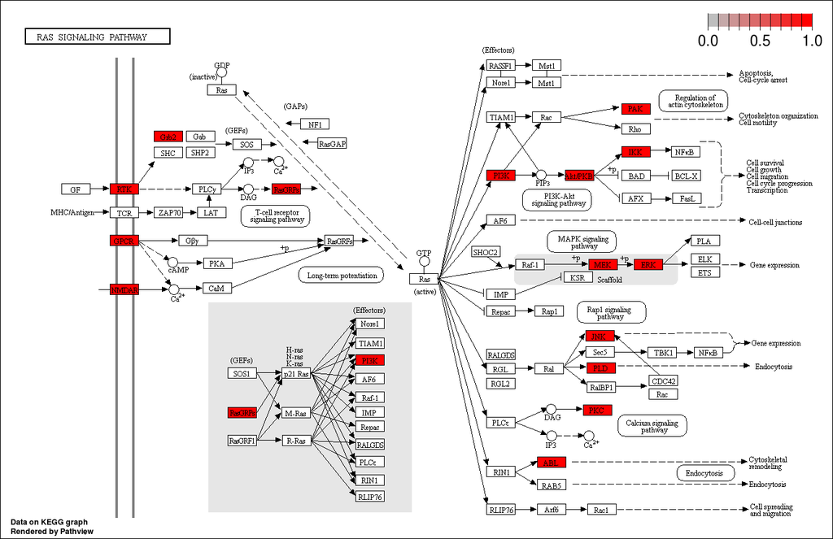

### References

Luo, W. and Brouwer C., Pathview: an R/Bioconductor package for pathway-based data integration and visualization. Bioinformatics, 2013, 29(14): 1830-1831, doi: 10.1093/bioinformatics/btt285  
Carson Sievert, Chris Parmer, Toby Hocking, Scott Chamberlain, Karthik Ram, Marianne Corvellec and Pedro Despouy (2016). plotly: Create Interactive Web Graphics via ‘plotly.js’. R package version 4.5.2. https://CRAN.R-project.org/package=plotly  
Shannon, Paul T., Mark Grimes, Burak Kutlu, Jan J. Bot, and David J. Galas. RCytoscape: tools for exploratory network analysis. BMC Bioinformatics 14, no. 1 (2013): 217.  
Ono K, Muetze T, Kolishovski G, Shannon P, Demchak, B. CyREST: Turbocharging Cytoscape Access for External Tools via a RESTful API [version 1; referees: 2 approved]. F1000Research 2015, 4:478.  
Guangchuang Yu, Qing-Yu He. ReactomePA: an R/Bioconductor package for reactome pathway analysis and visualization. Molecular BioSystems 2016, 12(2):477-479